# ripInverts - discussion paper content

# Import and prepare data

The following script imports data, cleans it and prepares a number of datasets. It also carries out a few analyses:

```r
source("../scripts/ripInverts-paper-code_1.R", chdir = T)
```

These are described in more detail below.

## Data sources

`field_data_selected_Aug2019.csv` contains all individual invertebrate records.

```r
head(obs_all)
```

| spp_name | abund_num | abund_char | river | event | event_code | date | year | evt_year | gridref | sample_type | location | repl_dateloc | repl_date | replicate | sadler_bell | search_pitfall | search_excavation | sample_duration | coord_precision | easting | northing |
| --- | --- | --- | --- | --- | --- | --- | --- | --- | --- | --- | --- | --- | --- | --- | --- | --- | --- | --- | --- | --- | --- |
| Actidium atterimum (match not found) | 6 | NA | Till | Till 2005 | Till_2005 | 03/07/1988 | 1988 | 2005 | NT997307 | hand_search | Doddington Bridge | Till 2005-HS-03071988-DoddingtonBridge | Till_2005-HS-03071988 | Till_2005-HS-DoddingtonBridge | NA | NA | NA | NA | 100 | 399700 | 630700 |
| Amara (Bradytus) consularis | 1 | NA | Till | Till 2005 | Till_2005 | 03/07/1988 | 1988 | 2005 | NT997307 | hand_search | Doddington Bridge | Till 2005-HS-03071988-DoddingtonBridge | Till_2005-HS-03071988 | Till_2005-HS-DoddingtonBridge | NA | NA | NA | NA | 100 | 399700 | 630700 |
| Bembidion (Princidium) punctulatum | 1 | NA | Till | Till 2005 | Till_2005 | 03/07/1988 | 1988 | 2005 | NT997307 | hand_search | Doddington Bridge | Till 2005-HS-03071988-DoddingtonBridge | Till_2005-HS-03071988 | Till_2005-HS-DoddingtonBridge | NA | NA | NA | NA | 100 | 399700 | 630700 |
| Bembidion (Ocydromus) tetracolum | 1 | NA | Till | Till 2005 | Till_2005 | 03/07/1988 | 1988 | 2005 | NT997307 | hand_search | Doddington Bridge | Till 2005-HS-03071988-DoddingtonBridge | Till_2005-HS-03071988 | Till_2005-HS-DoddingtonBridge | NA | NA | NA | NA | 100 | 399700 | 630700 |
| Bledius (Astycops) subterraneus | 5 | NA | Till | Till 2005 | Till_2005 | 03/07/1988 | 1988 | 2005 | NT997307 | hand_search | Doddington Bridge | Till 2005-HS-03071988-DoddingtonBridge | Till_2005-HS-03071988 | Till_2005-HS-DoddingtonBridge | NA | NA | NA | NA | 100 | 399700 | 630700 |
| Bracteon litorale | 1 | NA | Till | Till 2005 | Till_2005 | 03/07/1988 | 1988 | 2005 | NT997307 | hand_search | Doddington Bridge | Till 2005-HS-03071988-DoddingtonBridge | Till_2005-HS-03071988 | Till_2005-HS-DoddingtonBridge | NA | NA | NA | NA | 100 | 399700 | 630700 |

```r
skimr::skim_to_wide(obs_all) %>% select(type:sd)
```

| type | variable | missing | complete | n | min | max | empty | n_unique | top_counts | ordered | mean | count | sd |
| --- | --- | --- | --- | --- | --- | --- | --- | --- | --- | --- | --- | --- | --- |
| character | abund_char | 7551 | 551 | 8102 | 2 | 25 | 0 | 16 | NA | NA | NA | NA | NA |
| character | date | 785 | 7317 | 8102 | 10 | 10 | 0 | 111 | NA | NA | NA | NA | NA |
| character | event | 0 | 8102 | 8102 | 7 | 21 | 0 | 82 | NA | NA | NA | NA | NA |
| character | event_code | 0 | 8102 | 8102 | 7 | 20 | 0 | 82 | NA | NA | NA | NA | NA |
| character | evt_year | 38 | 8064 | 8102 | 4 | 4 | 0 | 15 | NA | NA | NA | NA | NA |
| character | gridref | 61 | 8041 | 8102 | 4 | 12 | 0 | 193 | NA | NA | NA | NA | NA |
| character | location | 14 | 8088 | 8102 | 2 | 31 | 0 | 194 | NA | NA | NA | NA | NA |
| character | repl_date | 254 | 7848 | 8102 | 14 | 32 | 0 | 432 | NA | NA | NA | NA | NA |
| character | repl_dateloc | 254 | 7848 | 8102 | 17 | 54 | 0 | 656 | NA | NA | NA | NA | NA |
| character | replicate | 254 | 7848 | 8102 | 13 | 44 | 0 | 425 | NA | NA | NA | NA | NA |

[output cut: 12 more lines]

```r
obs_all %>% select(event, event_code) %>% unique() %>% arrange(event)
```

| event | event_code |
| --- | --- |
| Allen 1987 | Allen_1987 |
| Alport 1999 | Alport_1999 |
| Ashop 1997 | Ashop_1997 |
| Beamish 2013 | Beamish_2013 |
| Bollin 2019 | Bollin_2019 |
| Camel 1999 | Camel_1999 |
| Camel 2003 | Camel_2003 |
| Camel tributary 2003 | CamelTrib_2003 |
| Carey 2003 | Carey_2003 |
| Creedy Yeo 1999 | CreedyYeo_1999 |

[output cut: 72 more lines]

`speciesmatch_further_correctionsAug2019.csv` is a lookup table of species names:

```r
head(spp_matched_corrected)
```

|  | old_name | match | wetland | coeleopteral | include | length.min | length.max | notes |
| --- | --- | --- | --- | --- | --- | --- | --- | --- |
| 1 | Abax parallelepipedus | Abax parallelepipedus | n |  | y |  |  |  |
| 2 | Abax paralleolpipedus | Abax parallelepipedus | n |  | y |  |  |  |
| 3 | Achomenus dorsalis | Anchomenus dorsalis | n |  | y |  |  |  |
| 4 | Acrotrichis sitkaensis | Acrotrichis (Acrotrichis) sitkaensis | n |  |  | #N/A | #N/A | obscure beetle no data in Pantheon |
| 5 | Actidium atterimum | Actidium aterrimum | #N/A |  |  | #N/A | #N/A | obscure beetle no data in Pantheon |
| 6 | Acupalpus dubius | Acupalpus dubius | y |  | y | 2.5 | 2.5 |  |

```r
skimr::skim_to_wide(spp_matched_corrected)
```

| type | variable | missing | complete | n | n_unique | top_counts | ordered |
| --- | --- | --- | --- | --- | --- | --- | --- |
| factor | coeleopteral | 0 | 646 | 646 | 2 | emp: 633, n: 13, NA: 0 | FALSE |
| factor | include | 0 | 646 | 646 | 3 | y: 425, emp: 196, n: 25, NA: 0 | FALSE |
| factor | length.max | 0 | 646 | 646 | 70 | emp: 169, 2: 36, 3.5: 35, 4: 34 | FALSE |
| factor | length.min | 0 | 646 | 646 | 66 | emp: 169, 4: 40, 2.5: 35, 1 | FALSE |
| factor | match | 0 | 646 | 646 | 560 | Zor: 7, Aeg: 3, Alo: 3, Bem: 3 | FALSE |
| factor | notes | 0 | 646 | 646 | 19 | emp: 427, to : 172, con: 16, A b: 10 | FALSE |
| factor | old_name | 0 | 646 | 646 | 646 | Aba: 1, Aba: 1, Ach: 1, Acr: 1 | FALSE |
| factor | wetland | 0 | 646 | 646 | 4 | y: 364, n: 263, #N/: 18, 0: 1 | FALSE |

`Riparian Beetle Assemblages July2019 ck added.xlsx` sheet 3 `Effort` is JW calculation of effort scores for each event

```r
head(effort_data)
```

| event_code | event | effort | pitfall | handsearch | author | grid_ref | n_records |
| --- | --- | --- | --- | --- | --- | --- | --- |
| Allen_1987 | Allen 1987 | 11 | 0 | 11 | Lott | SW92272557 | 61 |
| Alport_1999 | Alport 1999 | 3 | 2 | 1 | Eyre & Lott | SX37406218 | 75 |
| Ashop_1997 | Ashop 1997 | 4 | 2 | 2 | Eyre & Lott | SX36438819 | 56 |
| Beamish_2013 | Beamish 2013 | 5 | 1 | 4 | Webb & Mott | SX51855836 | 130 |
| Camel_1999 | Camel 1999 | 6 | 3 | 3 | Sadler & Bell | SX43687272 | 51 |
| Camel_2003 | Camel 2003 | 8 | 4 | 4 | Sadler & Bell | SO433418, SO433417 | 85 |

```r
skimr::skim_to_wide(effort_data)
```

| type | variable | missing | complete | n | min | max | empty | n_unique | mean | sd | p0 | p25 | p50 | p75 | p100 | hist |
| --- | --- | --- | --- | --- | --- | --- | --- | --- | --- | --- | --- | --- | --- | --- | --- | --- |
| character | author | 0 | 81 | 81 | 4 | 14 | 0 | 9 | NA | NA | NA | NA | NA | NA | NA | NA |
| character | event | 0 | 81 | 81 | 8 | 21 | 0 | 81 | NA | NA | NA | NA | NA | NA | NA | NA |
| character | event_code | 0 | 81 | 81 | 8 | 20 | 0 | 81 | NA | NA | NA | NA | NA | NA | NA | NA |
| character | grid_ref | 0 | 81 | 81 | 8 | 58 | 0 | 80 | NA | NA | NA | NA | NA | NA | NA | NA |
| numeric | effort | 0 | 81 | 81 | NA | NA | NA | NA | 6.04 | 2.56 | 2 | 4 | 6 | 8 | 13 |  |
| numeric | handsearch | 0 | 81 | 81 | NA | NA | NA | NA | 3.64 | 1.65 | 1 | 3 | 4 | 4 | 11 |  |
| numeric | n_records | 2 | 79 | 81 | NA | NA | NA | NA | 105.62 | 83.54 | 13 | 50.5 | 86 | 132.5 | 426 |  |
| numeric | pitfall | 0 | 81 | 81 | NA | NA | NA | NA | 2.4 | 1.53 | 0 | 1 | 2 | 3 | 7 |  |

```r
library(tidyverse)
library(cowplot)
library(iNEXT)
library(vegan)
```

```r
#generic graph settings
theme_doc <-  theme(axis.title = element_text(size = 10),
                    text=element_text(size=10),
                    plot.title = element_text(size = 11),
                    legend.key.width = unit(1.2,"cm"))
```

A total of

```r
#calculate total number of records
nrow(obs_all)
```

```
[1] 8102
```

records were collected as part of a programme that could be collated into individual survey events. A total of

```r
#calculate authors
```

```r
#calculate number of events
obs_all %>% filter(is.na(event))
```

| spp_name | abund_num | abund_char | river | event | event_code | date | year | evt_year | gridref | sample_type | location | repl_dateloc | repl_date | replicate | sadler_bell | search_pitfall | search_excavation | sample_duration | coord_precision | easting | northing |
| --- | --- | --- | --- | --- | --- | --- | --- | --- | --- | --- | --- | --- | --- | --- | --- | --- | --- | --- | --- | --- | --- |

```r
events_unique <- sort(unique(obs_all$event)[which(is.na(unique(obs_all$event))==FALSE)]); events_unique
```

```
 [1] "Allen 1987"            "Alport 1999"           "Ashop 1997"            "Beamish 2013"          "Bollin 2019"           "Camel 1999"
 [7] "Camel 2003"            "Camel tributary 2003"  "Carey 2003"            "Creedy Yeo 1999"       "Dane 2003a"            "Dane 2003b"
[13] "Dove 2013"             "Eden Read 2000"        "Eggleston Burn 2008"   "Erme 1999"             "Exe 1999"              "Fal 2002"
[19] "Fowey 2003a"           "Fowey 2003b"           "Frome 2017a"           "Frome 2017b"           "Frome 2017c"           "Gauntless 2008"
[25] "Harwood 2008"          "Lugg 2014a"            "Lugg 2014b"            "Lugg 2014c"            "Lugg 2014d"            "Lynher 2003"
[31] "Mawddach 2003"         "Monnow 2015"           "Otter 1999"            "Ottery 2003"           "Plym 2003"             "Rheidol 2004a"
[37] "Rheidol 2004b"         "Rheidol 2004c"         "Ribble 2019"           "Severn 2002a"          "Severn 2002b"          "Severn 2002c"
[43] "Severn 2002d"          "Severn 2003a"          "Severn 2003b"          "Severn Llandinam 1999" "South Tyne 2008"       "Tamar 2002"
[49] "Tame 2000"             "Taw 1999"              "Tees  2008a"           "Tees 2008b"            "Teign & Bovey 1998a"   "Teign & Bovey 1998b"
[55] "Teign 1999"            "Teme 1998"             "Thrushel 1999"         "Till 2005"             "Till 2013"             "Torridge 1999"
[61] "Towy 1998"             "Towy 2002a"            "Towy 2002b"            "Towy 2002c"            "Towy 2003a"            "Towy 2003b"
[67] "Towy 2003c"            "Tywi 1998"             "unknown"               "Usk 1998"              "Wear 2005"             "Wear 2008"
[73] "Wooler Water 2013"     "Wye 1998"              "Wye 2014a"             "Wye 2014b"             "Wye 2014c"             "Wye 2014d"
[79] "Wye 2014e"             "Wye 2014f"             "Yarty 1999"            "Yealm 2003"
```

```r
length(events_unique)
```

```
[1] 82
```

events that occurred between

```r
event_lookup %>% group_by(evt_year) %>% summarise(eventsperyear = n())
```

| evt_year | eventsperyear |
| --- | --- |
| 1987 | 1 |
| 1997 | 1 |
| 1998 | 7 |
| 1999 | 12 |
| 2000 | 2 |
| 2002 | 9 |
| 2003 | 17 |
| 2004 | 3 |
| 2005 | 2 |
| 2008 | 7 |

[output cut: 6 more lines]

records collected between

```r
#calculate date range
table(obs_all$year)
```

```
1987 1988 1997 1998 1999 2000 2001 2002 2003 2004 2005 2008 2013 2014 2015 2017 2019
  61   33  130  581  785   95   22 1298  672  412  182  407  540  106 1955  569  254
```

```r
#obs_all %>% filter(year == "1987") %>% count(event, river, location, sample_type)
#obs_all %>% filter(river == "Tees") %>% count(event, river)
#obs_all %>% filter(river == "Wye") %>% count(event, river)
```

## grid references

```r
obs_all %>% count(gridref) %>% arrange(-n)
```

| gridref | n |
| --- | --- |
| SO02038724 | 210 |
| SN74913238 | 176 |
| SN75273268 | 176 |
| SO288461 | 173 |
| SO01928705 | 161 |
| SO02428808 | 160 |
| SK265273 | 158 |
| SO02418816 | 152 |
| SN63732281 | 133 |
| NU045068 | 127 |

[output cut: 184 more lines]

```r
obs_all %>% count(event_code, coord_precision)
```

| event_code | coord_precision | n |
| --- | --- | --- |
| Allen_1987 | 100 | 61 |
| Alport_1999 | 100 | 74 |
| Ashop_1997 | 100 | 56 |
| Beamish_2013 | 100 | 127 |
| Bollin_2019 | NA | 160 |
| Camel_1999 | 100 | 51 |
| Camel_2003 | 10 | 85 |
| CamelTrib_2003 | 10 | 26 |
| Carey_2003 | 10 | 20 |
| CreedyYeo_1999 | 100 | 78 |

[output cut: 79 more lines]

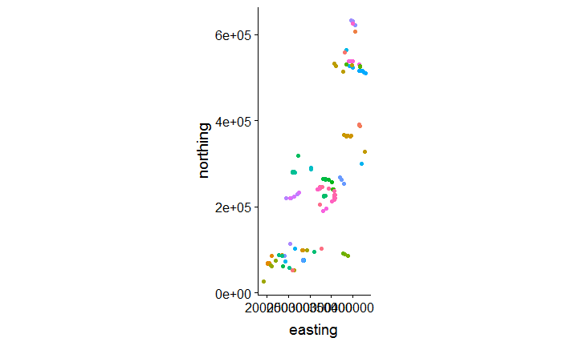

```r
ggplot(obs_all, aes(easting, northing)) +
  geom_point(aes(colour = event)) + coord_equal() + theme(legend.position = "none")
```

## richness and scores

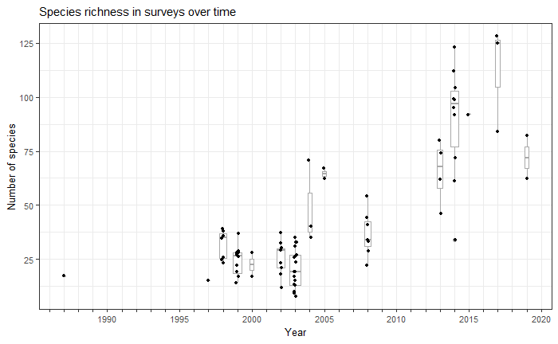

```r
#richness by year
#summarise species richness per event
graphdata <- obs_all %>%
  select(spp_name, event_code, evt_year) %>%
  unique() %>%
  group_by(event_code, evt_year) %>%
  summarise(richness = n()) %>%
  filter(evt_year != "NA") %>%
  mutate(evt_year = as.numeric(evt_year))
ggplot(graphdata, aes(x = evt_year, y = richness, group = as.factor(evt_year))) +
  geom_boxplot(varwidth = T, colour = "darkgrey") +
  geom_point(position = position_jitter(width = 0.08, height = 0.3), size = 0.9)+
  scale_x_continuous(breaks = seq(1985,2020, by = 1),
                     labels = c("1985", "", "", "", "",
                                "1990", "", "", "", "",
                                "1995", "", "", "", "",
                                "2000", "", "", "", "",
                                "2005", "", "", "", "",
                                "2010", "", "", "", "",
                                "2015", "", "", "", "", "2020")) +
  scale_y_continuous(breaks = seq(0, 250, by = 25))+
  labs(title = "Species richness in surveys over time",
       x = "Year", y = "Number of species") +
  theme_bw() +
  theme_doc +
  theme(panel.grid.minor.x = element_blank())
```

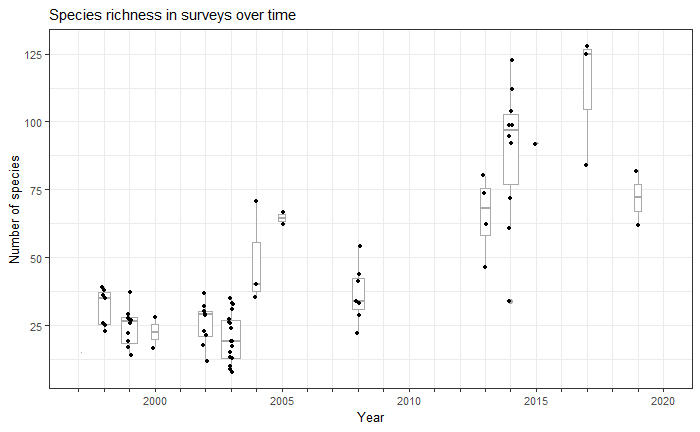

```r
#or cropped by leaving out the 1987 records
ggplot(graphdata, aes(x = evt_year, y = richness, group = as.factor(evt_year))) +
  geom_boxplot(varwidth = T, colour = "darkgrey") +
  # geom_violin() +
  geom_point(position = position_jitter(width = 0.08, height = 0.3), size = 0.9)+
  scale_x_continuous(breaks = seq(1997,2020, by = 1), limits = c(1997, 2020),
                     labels = c("", "", "", "2000", "", "", "", "",
                                "2005", "", "", "", "", "2010", "", "", "", "",
                                "2015", "", "", "", "", "2020")) +
  scale_y_continuous(breaks = seq(0, 250, by = 25))+
  labs(title = "Species richness in surveys over time",
       x = "Year", y = "Number of species") +
  theme_bw() +
  theme_doc +
  theme(panel.grid.minor.x = element_blank())
```

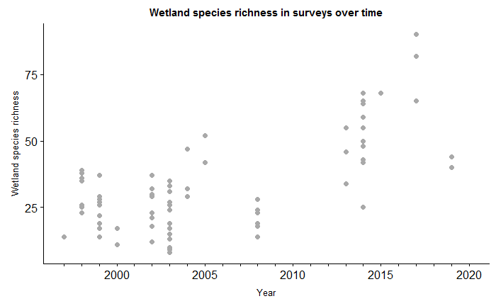

### Effort

```r
#effort summarised by JW
effort <- effort_data %>% select(event_code, hand_search = handsearch, pitfall, effort_score = effort); effort
```

| event_code | hand_search | pitfall | effort_score |
| --- | --- | --- | --- |
| Allen_1987 | 11 | 0 | 11 |
| Alport_1999 | 1 | 2 | 3 |
| Ashop_1997 | 2 | 2 | 4 |
| Beamish_2013 | 4 | 1 | 5 |
| Camel_1999 | 3 | 3 | 6 |
| Camel_2003 | 4 | 4 | 8 |
| CamelTrib_2003 | 2 | 2 | 4 |
| Carey_2003 | 1 | 1 | 2 |
| CreedyYeo_1999 | 3 | 3 | 6 |
| Dane_2003_a | 3 | 3 | 6 |

[output cut: 71 more lines]

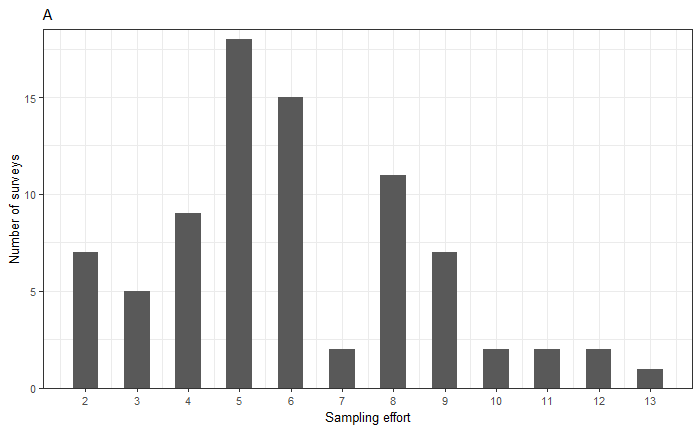

```r
plot_effort <- ggplot(effort, aes(x = effort_score)) +
  geom_histogram(binwidth = 0.5) +
  scale_x_continuous(breaks = 0:max(effort$effort_score)) +
  scale_y_continuous(expand = expand_scale(add =c(0,0.5))) +
  labs(x = "Sampling effort", y = "Number of surveys", title = "A") +
  theme_bw()+  theme_doc
plot_effort
```

[output not shown]

[output cut: 71 more lines]

```r
wetland_effort <-
  obs_all %>% select(spp_name, event_code) %>%
  left_join(select(effort, event_code, effort_score)) %>%
  left_join(select(spp_lookup_joined, species, 'Wetland species'),
            by = c("spp_name" = "species")) %>%
  rename(wetland_spp = 'Wetland species') %>%
  unique() %>%
  group_by(event_code, effort_score) %>%
  count(wetland_spp) %>%
  filter(wetland_spp == 1) %>%
  filter(event_code != "unknown")
wetland_effort %>% arrange(-n)
```

| event_code | effort_score | wetland_spp | n |
| --- | --- | --- | --- |
| Frome_2017_b | 5 | 1 | 90 |
| Frome_2017_a | 5 | 1 | 82 |
| Lugg_2014_d | 8 | 1 | 68 |
| Monnow_2015 | 5 | 1 | 68 |
| Frome_2017_c | 5 | 1 | 65 |
| Lugg_2014_a | 8 | 1 | 65 |
| Wye_2014_e | 8 | 1 | 64 |
| Wye_2014_b | 9 | 1 | 59 |
| Dove_2013 | 5 | 1 | 55 |
| Lugg_2014_c | 8 | 1 | 55 |

[output cut: 71 more lines]

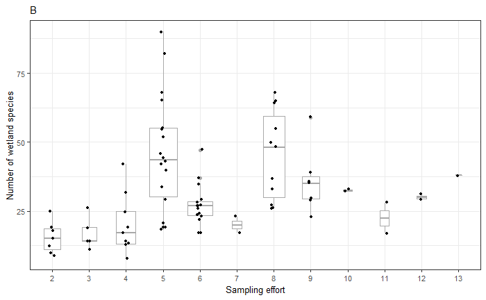

```r
plot_wetland_effort <- ggplot(wetland_effort,
                              aes(x = as.factor(effort_score), y = n),
                              fill = as.factor(effort_score))+
  geom_boxplot(varwidth = T, colour = "darkgrey") +
  #geom_violin(scale = "width")+
  geom_point(position = position_jitter(width = 0.08, height = 0.3), size = 0.9)+
  labs(x = "Sampling effort", y = "Number of wetland species", title = "B") +
  theme_bw() +
  theme_doc

plot_wetland_effort
```

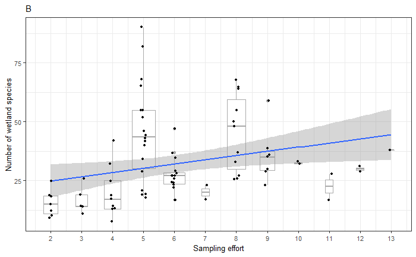

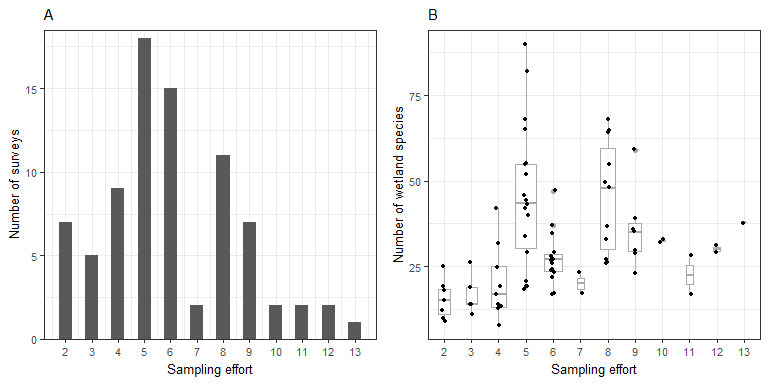

## sample type: does it matter

```r
adon1
```

```
Permutation test for adonis under reduced model
Terms added sequentially (first to last)
Permutation: free
Number of permutations: 120

vegan::adonis2(formula = selected_data ~ river + event_code + sample_type, data = selected_env, permutations = 120, method = "jaccard", by = "terms")
             Df SumOfSqs      R2      F   Pr(>F)
river        48   53.779 0.29231 3.5425 0.008264 **
event_code   33   17.207 0.09353 1.6487 0.008264 **
sample_type   1    2.614 0.01421 8.2656 0.008264 **
Residual    349  110.379 0.59995
Total       431  183.979 1.00000
---
Signif. codes:  0 ‘***’ 0.001 ‘**’ 0.01 ‘*’ 0.05 ‘.’ 0.1 ‘ ’ 1
```